# Predicting the Oscars

12/14/2018

# 1 Stating the Question

Can we predict if a movie will win at least one Oscar?

## 1.1 Data

We will use a dataset that [BigMl](https://bigml.com/) [put together](https://bigml.com/user/academy_awards/gallery/dataset/5a94302592fb565ed400103b) and used to train a deep neural network to get [perfect predictions](https://blog.bigml.com/2018/03/01/predicting-the-2018-oscar-winners/) for the 8 categories they targeted for 2018 using data on oscar eligible films from the years 2000-2017. However, this does not mean their model is perfect, as the prediction accuracy on their training set was not 100% when they tested their model on years prior to 2018.

Note: the oscars have 24 categories, and this dataset only recorded whether a film won 8 of those awards.

Although our data came from a machine learning company, it still needed a plethora of pre-processing before random forest or logistic regression models could be trained on it.

# 2 Exploratory Data Analysis (EDA)

*Note: Goto the RMarkdown file for the list of libraries that are imported. They have been redacted for brevity.*

## 2.1 First Contact

Let’s load the data and see what features we have and how large our dataset is:

```r
oscars <- read_csv("oscars.csv", col_types = cols())
#View(head(oscars)) # Go to the .Rdm file and uncomment this line
# if you want to have a look at the data
dim(oscars)
```

```
## [1] 1183  119
```

We have 16 binary features saying whether a movie won or was nominated for one of the following Oscars’ categories:

1. Best Picture
2. Best Director
3. Best Actor
4. Best Actress
5. Best Supporting Actor
6. Best Supporting Actress
7. Best Adapted Screenplay
8. Best Original Screenplay

As we are concerned with predicting whether a movie will win at least one Oscar or not, we will create such column (to be called `Oscars_won_some`) using these, and drop them after doing so. Note that we are only using data from 8 categories, which is what BigML had. Then we have another column called `Oscars_nominated`, which says for how many categories a movie was nominated for, including the ones not mentioned before. `Oscars_nominated_categories` is its analogous but on text form, indicating the specific nominated categories. We will also drop this one.

The rest of the features all follow the same pattern: first we have `award_name_won`, which says how many categories of such award the movie won, and then we have `award_name_won_categories`, a string specifying these categories. `award_name_nominated` and `award_name_nominated_categories` are the same but for nominations instead of wins. We will only use the numerical features, and drop the categorical ones.

This table summarizes some of the actions we will take to clean up the data:

| Variable | Notes/Actions to Take |
| --- | --- |
| year | Used for Splitting data. Train and Test Split |
| certificate | Encode as factor/numeric. Feature Manipulation |
| genre | One-hot encode. Feature Manipulation |
| gross | Modify to account for inflation. Feature Manipulation |
| release_date.month | Use to create `season`. Feature Manipulation |
| release_date.year | Dropped due to irrelevance. Feature Manipulation |
| release_date.day-of-month | Dropped due to irrelevance. Feature Manipulation |
| release_date.day-of-week | Dropped due to irrelevance. Feature Manipulation |
| movie | Dropped due to irrelevance. Feature Manipulation |
| movie_id | Dropped due to irrelevance. Feature Manipulation |
| synopsis | Dropped due to irrelevance. Feature Manipulation |
| release_date | Dropped due to irrelevance. Feature Manipulation |

## 2.2 Missing Values

Having looked and experimented with several ways of imputing the missing values, we have decided to handle imputing on only the set of variables we expect to apply to the model. See section Imputation below.

While normally the missingness is the first thing to be dealt with, in our case, due to the high dimensionality of the dataset, it makes more sense to deal with it after getting rid of all the features we do not want to use.

## 2.3 Quality Checks

Now let us make some quality checks, before diving into preprocessing.

The range of years in which our movies are released:

```r
tmp <- sort(unique(oscars$year))
head(tmp, n = 1)
```

```
## [1] 2000
```

```r
tail(tmp, n = 1)
```

```
## [1] 2017
```

The number of Movies per Year:

```r
table(oscars$year)
```

```
##
## 2000 2001 2002 2003 2004 2005 2006 2007 2008 2009 2010 2011 2012 2013 2014
##   71   67   67   63   71   69   71   68   64   67   69   71   67   73   68
## 2015 2016 2017
##   66   61   30
```

There are about 70 movies per year, but for 2017 we only have 30. We are thus not going to use the data from 2017, and will instead focus on 2000-2016 data, which is clearly more complete:

```r
# Lied about not doing yet any preprocessing...
oscars = filter(oscars, year != 2017)
```

To verify the data is consistent, we will verify that we have only 17 winners for each category (one winner per year, per category). Here is the number of winners per category across the remaining dataset:

```r
# Pattern to get only the relevant columns
pat.oscar_won <- "Oscar_.*_won$"
pat.oscar_nom <- "Oscar_.*_nominated$"

t(oscars %>%
  select(matches(pat.oscar_won)) %>%
  mutate_at(vars(matches(pat.oscar_won)),
            funs(ifelse(. == "No", 0, 1))) %>%
  summarise_all(sum))
```

```
##                                   [,1]
## Oscar_Best_Picture_won              17
## Oscar_Best_Director_won             17
## Oscar_Best_Actor_won                17
## Oscar_Best_Actress_won              17
## Oscar_Best_Supporting_Actor_won     17
## Oscar_Best_Supporting_Actress_won   17
## Oscar_Best_AdaScreen_won            17
## Oscar_Best_OriScreen_won            17
```

Our Oscar category win variables appear to be consistently showing what we expected.

Note that from above, and remembering that we have 1183 observations, we know that our data is heavily imbalanced. Out of all the films released each year, few are nominated for an oscar. Out of those, even fewer win one, meaning that our target variable will be biased towards non-winners

Moving on, let us also make sure that `awards_wins` does not contain any information regarding the Oscars, as this would not be known to us when making future predictions. To verify this we used a spot-check, and confirmed that the number of non-oscar awards won is equal to `awards_wins` as we expected:

```r
# Gets the movies that won Oscars for best picture
oscars_won_best_picture <- subset(oscars, Oscar_Best_Picture_won == "Yes")
#dim(oscars_won_best_picture)
# Gets the first movie of such list
lord_of_the_rings_king <- head(oscars_won_best_picture, 1)
# Gets the number of awards it won, not counting the Oscars
num_awards_won <- 0
# For every column name in the Series
for (i in names(lord_of_the_rings_king)){
  # If "won"" is in the column name at the end
  if(grepl("won$", i) == TRUE){
    # And if "Oscar" is not in the column name
     if(grepl("Oscar", i) == FALSE){
         # Add to num_awards_won the value of such column
         num_awards_won = num_awards_won + lord_of_the_rings_king[c(i)][[1]]
      }
  }
}
# Verify the value of awards_wins makes sense
lord_of_the_rings_king[c("awards_wins")][[1]] == num_awards_won
```

```
## [1] TRUE
```

# 3 Data Preprocessing

## 3.1 Feature Manipulation

First we create our target feature, the number of oscars a film won, by counting the number of oscars each film won in the 8 provided categories.

```r
# sum number of wins identified per row for cols
tmp.won <- rowSums(
  oscars %>%
    mutate_at(
      vars(matches(pat.oscar_won)),
      funs(ifelse(. == "No", 0, 1))
    ) %>% select(matches(pat.oscar_won))
  )

# set win count variable in oscars df
oscars <- oscars %>%
  mutate(Oscars_win_count = tmp.won)
```

Now that we have our `Oscars_win_count`, let us verify that the count information is correct for a couple specific observations:

```r
# Validation
oscars_won_best_picture <- filter(oscars, Oscar_Best_Picture_won == 'Yes')
# This movie won 3 oscars, let's see if it checks out
oscars_won_best_picture$Oscars_win_count[1] == 3
```

```
## [1] TRUE
```

```r
# This movie won 2 oscars, let's see if it checks out
oscars_won_best_picture$Oscars_win_count[2] == 2
```

```
## [1] TRUE
```

Now we will encode `Oscars_won_some` as the target feature for our models, based on the `Oscars_win_count` we just verified:

```r
# Encodes as factor
oscars <- oscars %>% mutate(
  Oscars_won_some = factor(ifelse(Oscars_win_count > 0, "Yes", "No"))
)
```

Now, let us encode `certificate`, which contains information most people call the rating of a movie. The ranking concept described [here](https://www.wikiwand.com/en/Motion_Picture_Association_of_America_film_rating_system) and here, indicates that we can encode this variable as either a factor, or a quantitative variable (if we want to maintain the order). We were not certain which approach to take, so we attempted both:

1. Turn `certificate` into a factor, which will then be one-hot-encoded by R when running Logistic Regression.
2. Encode `certificate` as a numeric, preserving the order.

It turned out that option 2 worked best for predicting the target feature.

We have the following values in the `certificate` feature:

```r
# Prints the unique values of the certificate column
unique(oscars$certificate)
```

```
## [1] "PG-13"     "G"         "R"         "PG"        "Not Rated" "Unrated"
## [7] NA          "TV-MA"
```

We weren’t sure how quantify the `Not Rated` and `Unrated` values, as it isn’t immediately obvious what order they have relative to each other.

The following movies are `Not Rated`, or `Unrated`:

```r
# Prints the movies "Unrated" and "Not Rated"
subset(oscars, certificate == "Not Rated" | certificate == "Unrated")[c("movie")]
```

```
## # A tibble: 18 x 1
##    movie
##    <chr>
##  1 Ken Park
##  2 Zus & zo
##  3 Evil
##  4 The Secret of Kells
##  5 Beaufort
##  6 Il Divo
##  7 Death Proof
##  8 Revanche
##  9 In the Loop
## 10 Outside the Law
## 11 Chico & Rita
## 12 Dogtooth
## 13 War Witch
## 14 The Broken Circle Breakdown
## 15 The Great Beauty
## 16 The Invitation
## 17 Tangerines
## 18 Embrace of the Serpent
```

Because only a small number of observations fall into these categories, we will remove them. They would only make us create more dummy variables for the model to train, and none of them won any oscars, as we confirm below:

```r
# Gets the indexes of such rows
not_rated_index = as.numeric(rownames(subset(oscars, certificate == "Not Rated")[c("movie")]))
unrated_index =  as.numeric(rownames(subset(oscars, certificate == "Unrated")[c("movie")]))

# Checks if any of them won an oscar
for(i in 1:nrow(oscars[not_rated_index, ])){
  if(oscars[not_rated_index, ]$Oscars_won_some[i] == "Yes"){
    print("Yes")
  }
}
for(i in 1:nrow(oscars[unrated_index, ])){
  if(oscars[unrated_index, ]$Oscars_won_some[i] == "Yes"){
    print("Yes")
  }
}

#dim(oscars)
# https://github.com/tidyverse/dplyr/issues/3196
oscars = oscars %>%
  filter(certificate != "Not Rated"
         | is.na(certificate)) %>%
  filter(certificate != "Unrated"
         | is.na(certificate))
#dim(oscars)
```

Now let us treat the missing values, which appears the be caused by the movies not actually being rated. The number of observations that don’t have entries for the `certificate` feature:

```r
sum(is.na(oscars$certificate))
```

```
## [1] 10
```

Verifying that none of these entries won the Oscars:

```r
titles_missing_values = oscars[is.na(oscars$certificate), ]$movie
#titles_missing_values

for(i in titles_missing_values){
  if(subset(oscars, movie == i)$Oscars_won_some == "Yes"){
    print("Yes")}
}
```

They did not, so let’s simply remove these observations.

```r
oscars = oscars %>% filter(is.na(certificate) == FALSE)
#dim(oscars)
```

Now let us encode the `certificate` features:

```r
#unique(oscars$certificate)
oscars = oscars %>% mutate(certificate = replace(certificate, certificate == "PG-13", 3))
oscars = oscars %>% mutate(certificate = replace(certificate, certificate == "G", 1))
oscars = oscars %>% mutate(certificate = replace(certificate, certificate == "R", 4))
oscars = oscars %>% mutate(certificate = replace(certificate, certificate == "PG", 2))
oscars = oscars %>% mutate(certificate = replace(certificate, certificate == "TV-MA", 5))
oscars$certificate = as.numeric(oscars$certificate)
#unique(oscars$certificate)
```

*Note: The code for attempting approach 1 is available in the Rmd file, but will not run for the html file. To run it use the function `certificate_factor` by uncommenting the line that executes it.*

Moving on to `genre`, now we will manually create dummy variables, because we have movies with more than one genre, and simply turning it into a factor would result on too many levels:

```r
# get all of the values parsed by |'s
genre_unique = unique(oscars$genre)
# get the actual unique values
soup = c()
for(i in 1:length(genre_unique)){
  soup = append(soup,unlist(strsplit(genre_unique[i],"\\|")))
}
new_cols = unique(soup)

# create a dataframe where the column names are the unique genres
gen = data.frame(matrix(nrow=nrow(oscars),ncol=length(new_cols)))
colnames(gen) = new_cols

for(i in 1:ncol(gen)){
  # iterate over columns
  for(j in 1:nrow(gen)){
    # then rows
    # if the string with the column name is in the string for the awards_won column in the original
    # dataset.... give that variable a 1 in the new dataset
    if((grepl(colnames(gen[i]),oscars$genre[j])==TRUE)){
      gen[j,i] = 1
      }
    else{
      gen[j,i] = 0
    }
  }
}

# we add the prefix "genre", so that the varaibles are easier to identify.
colnames(gen) = paste("genre",colnames(gen),sep="_")

# get rid of the mispelling of history... somehow some moves were classified as histor and history
# assume music and musical are the same genre.
gen$genre_History = gen$genre_History + gen$genre_Histor
gen$genre_Musical = gen$genre_Musical + gen$genre_Music


# check for duplicates
#max(gen$genre_History)
#max(gen$genre_Musical)
# we have them in both, so remove them.

for(i in 1:length(gen$genre_History)){
  if(gen$genre_History[i]>1){
    gen$genre_History[i] =1
  }
}

for(i in 1:length(gen$genre_Musical)){
  if(gen$genre_Musical[i]>1){
    gen$genre_Musical[i] =1
  }
}

# select the columns that are duplicated
DropCols = c("genre_Histor","genre_Music")
# remove them from the datframe.

gen = gen[,!colnames(gen)%in%DropCols]

oscars = cbind(oscars,gen)

# Changing 0 to "No" and 1 to "Yes" and converting to factor
for(i in names(gen)){
  oscars[c(i)][[1]] = ifelse(oscars[c(i)][[1]] == 1, "Yes", "No")
  oscars[c(i)][[1]] = factor(oscars[c(i)][[1]])
}
```

We found that only one movie is a documentary, so we must drop the (`genre_Documentary`) column from our analysis because if we want to use k-fold cross validation to evaluate our models, there will be at least one instance where our training set will contain a factor variable that contains only one level, which provides no information.

```r
oscars <- oscars %>% select(-genre_Documentary)
```

The next feature that needs some manipulation is `gross`. The value of the dollar changed from 2000 to 2016, so we’ll need to adjust the values we have to be based on something consistent. We’ll use the value of the dollar in the year 2000 as a common unit. To convert between 2001 through 2016 dollar amounts, and the 2000 dollar amounts we’ll need something to use as a conversion factor. We’ll use the Consumer Price Index (CPI) data provided by the United States Bureau of Labor Statistics, to get that conversion factor. Their [site](https://data.bls.gov/timeseries/CUUR0000SA0), provides CPI data by month output to an excel sheet. We opted to include the Annual average prior to download, and are basing our conversions on that. After cleaning the data up in excel, we saved it off in `CPI_20181201.csv`, which we’ll load, and apply now:

```r
# Pull in Consumer Price Index Data from
# Burea of Labor Statistics to account for inflation
cpi <- read_csv('CPI_20181201.csv', col_types = cols())

# data ranged from 2000 (1) to 2017 (18)
# so... year mod 2000 + 1 is the indexing scheme.
# NOTE: if cpi csv file is changed the indexing scheme will need updating
cpif <- function(year) {
  idx <- year %% 2000 + 1
  cpi$Annual[idx]
}

oscars = oscars %>% mutate(
  # Adjust gross field by Consumer Price Index.
  # cpif provides annual average CPI for specified year
  # data provided by the Burea of Labor Statistics website
  # (implementation included in full Rmd document)
  sc.gross = gross * cpif(2000)/cpif(year) # "In 2000 dollars"
) %>%
  # mutate oscars won and oscars nominated cols/variables to factor types
  mutate_at(vars(matches(pat.oscar_won)), funs(factor)) %>%
  mutate_at(vars(matches(pat.oscar_nom)), funs(factor))
```

To visually confirm that the adjustments to `gross` (stored in `sc.gross`), are valid, we’ll display the average gross amount per year from the dataset, both with and without the adjustment:

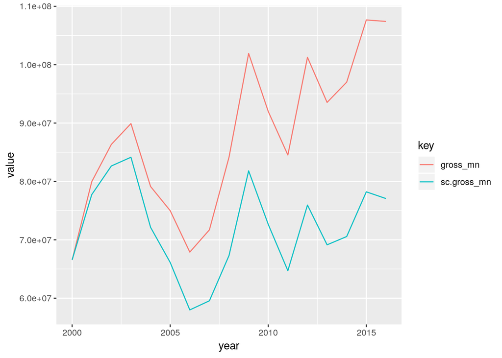

```r
# Validation of currency adjustment
currency_info <- oscars %>% select(
  gross, sc.gross, year
) %>% group_by(year) %>% summarize(
  gross_mn = mean(gross, na.rm = TRUE),
  sc.gross_mn = mean(sc.gross, na.rm = TRUE)
)

currency_info %>%
  gather(key, value, gross_mn, sc.gross_mn) %>%
  ggplot(aes(x=year, y=value, colour=key)) +
  geom_line()
```

```r
season <- function(month) {
  retVal <- "Fall"

  if (month <= 2) {
    "Winter" # Winter [December, February]
  } else if (month <= 5) {
    retVal <- "Spring"  # Spring [March, May]
  } else if (month <= 8) {
    retVal <- "Summer" # Summer [June, August]
  } else if (month <= 11) {
    retVal <- "Fall" # Fall   [September, November]
  } else {
    retVal <- "Winter"
  }

  return (retVal)
}

oscars <- oscars %>%
  rowwise() %>%
  mutate(seasons = season(release_date.month))
oscars$seasons = factor(oscars$seasons)
```

All that is left is dropping the columns that we don’t want to use for the model training:

```r
drop.cols <- c(
  'movie',
  'movie_id',
  'synopsis',
  'gross', # dropping gross b/c gross.sc contains scaled values
  'Oscars_win_count',
  'release_date',
  'Oscar_nominated_categories',
  'genre',
  'release_date.year',
  'release_date.day-of-month',
  'release_date.day-of-week',
  'release_date.month')
oscars <- oscars %>%
  select(-one_of(drop.cols)) %>%
  select(-matches("categories$")) %>%
  select(-matches("Oscar_.*_won$"))
```

## 3.2 Imputation

Let us figure out how to handle any missing values, now that we have removed some of the columns based on the EDA from above.

```r
missing_per_column = sapply(oscars, function(x) sum(is.na(x)))
missing_per_column[missing_per_column != 0]
```

```
##      metascore   user_reviews critic_reviews     popularity       sc.gross
##             10              7              7            101             16
```

Using the `tidyimpute` package, we will impute the missing values identified above based on the mean. After some consideration, this seemed the best approach to avoid having the imputation inject error into our model:

```r
oscars <- oscars %>% impute_mean(
  metascore,
  user_reviews,
  critic_reviews,
  popularity,
  sc.gross
)
```

## 3.3 Train and Test Split

Let us move on to splitting the data. We are going to use data from 2000 to 2012 (~75%) for training and from 2013 to 2016 for testing. There is no need to stratify as we are not doing a random split, that is, both train and test sets will have the same proportion of class labels, because we are splitting by `year`:

```r
# Splits by years
oscars_train <- subset(oscars, year %in% c(2000:2012))
oscars_test <- subset(oscars, year %in% c(2013:2016))

# Drops year
oscars <- select(oscars, -year)
oscars_train <- select(oscars_train, -year)
oscars_test <- select(oscars_test, -year)

# Gets the target
y_train = oscars_train$Oscars_won_some
y_test = oscars_test$Oscars_won_some
```

## 3.4 Standardization

The last step before we can train our models is standardizing. By default, R omits standardizing factor variables, so we do not need to be concerned about that. We will follow [this method](https://machinelearningmastery.com/pre-process-your-dataset-in-r/):

```r
scaleParam <- preProcess(oscars_train, method=c("center", "scale"))
oscars_train <- predict(scaleParam, oscars_train)
oscars_test <- predict(scaleParam, oscars_test)
```

# 4 Model Building

We decided to tackle the prediction problem using Logistic Regression and Random Forest classifiers due to the categorical nature of the dependent variable. Apart from using our train and test sets to evaluate our models, we will also use 3-fold stratified cross-validation to test the variance of our predictive accuracy. We chose stratified cross-validation to ensure the proportion of class labels is maintained in each of the splits. We chose 3-folds instead of the standard 10-folds, because if we were to use smaller splits, we would risk having too few observations in the testing data, and thus our comparitive metrics would not be reliable.

## 4.1 Logistic Regression

Due to the high dimensionality of our dataset, we could not train a logistic regression model with all of our features. We tried two approaches to create sparse models; manual feature selection and forward selection using BIC as an evaluation metric.

### 4.1.1 Logistic Regression - Manual Selection

Logistic Regression model using manual feature selection. We used intuition and experimentation to come up with 12 features:

```r
# Trains the model
model.glm.subset <-  glm(Oscars_won_some~certificate +
                           duration +
                           rate +
                           metascore +
                           votes +
                           user_reviews +
                           critic_reviews +
                           popularity +
                           awards_wins +
                           awards_nominations +
                           sc.gross +
                           seasons,
                         family = binomial(link = "logit"),
                         data = oscars_train)
```

The most significant features, appear to be `certificate`, `user_reviews`, and `award_wins`.

Testing the Model:

```r
# Tests the model
model.glm.subset.test <- predict.glm(model.glm.subset,oscars_test,type='response')

cm <- confusionMatrix(factor(ifelse(model.glm.subset.test > .5,"Yes","No")), y_test)

cm$table
```

```
##           Reference
## Prediction  No Yes
##        No  234   9
##        Yes   6  12
```

```r
cm$overall[1]
```

```
##  Accuracy
## 0.9425287
```

```r
cm$overall[5]
```

```
## AccuracyNull
##    0.9195402
```

The model’s hit rate is ~94%. But we need to consider that most of the movies in our dataset will not win an Oscar (~92%, as shown by AccuracyNull above). Our hit rate is higher than the percentage of movies that did not win Oscars, implying that our model’s predictive capability, using a 50% threshold, is an improvement over simply using our target’s distribution to predict the winners (this means classifying all movies as not winners).

Although we had a high True Negative rate (~98%), our True positive rate was lower (~57%). This does not show in our hit rate, because only ~8% of our movies actually won Oscars. Let us take a look at the ROC Curves, to see if a different threshold quantity would have a significant impact on the predictive capability of the model:

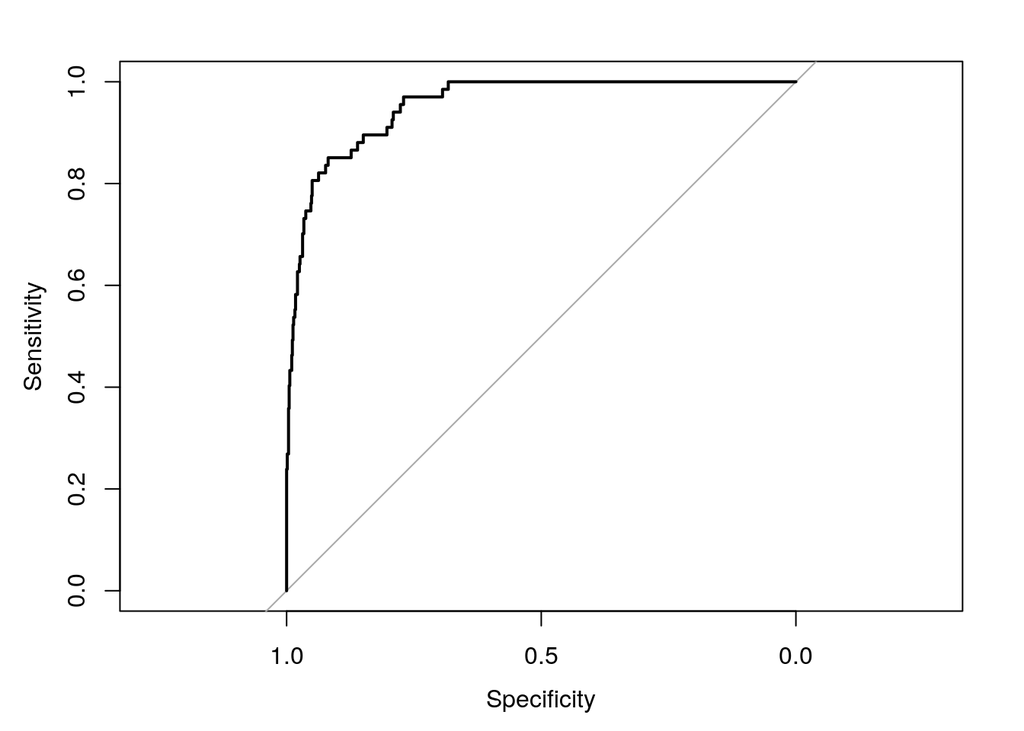

```r
model.glm.subset.prob=plogis(predict.glm(model.glm.subset, type = c("response")))
#head(prob)
model.glm.subset.h <- roc(Oscars_won_some~model.glm.subset.prob, data=oscars_train)
plot(model.glm.subset.h)
```

```r
# Area Under the Curve
auc(model.glm.subset.h)
```

```
## Area under the curve: 0.9548
```

The area under the curve is ~95%, which is greater than the no data rate of ~92% that we found before, implying that our model discriminates well at different thresholds.

Before moving on to step-wise forward selection, we shall verify our results using cross-validation:

```r
# cross_validate function for looping over multiple stratified splits, training a model, and testing.
cross_validate <- function(data, fTrain, fHitRate) {
  folds <- KFold(data$Oscars_won_some, n = 3,
                 stratified = TRUE, seed = 42)
  # Gets a list with the number of folds
  list_ = 1:length(folds)
  # Gets a list to store the accuracy for each split
  scores = c()
  # For each fold
  for(i in list_){
    # Gets the indexes for getting the training data
    list_train = list_[-i]
    train_index = c(folds[[list_train[1]]], folds[[list_train[2]]])
    # Gets the index for the testing data
    test_index = folds[[i]]
    # Splits between training and testing
    cv.train = data[train_index, ]
    cv.test = data[test_index, ]
    # Standardizes the new data
    scaleParam <- preProcess(cv.train, method=c("center", "scale"))
    cv.train <- predict(scaleParam, cv.train)
    cv.test <- predict(scaleParam, cv.test)
    # Trains the model
    trained.model <- fTrain(cv.train)
    # Tests the model
    y.predicted <-
      predict(
        trained.model,
        cv.test,
        type='response')

    score <- fHitRate( y.predicted, cv.test$Oscars_won_some)
    # Appends the score to the list
    scores = c(scores, score)
  }
  return(scores)
}

# Define function for training the model in the cross-validation loop
model.glm.subset.fTrain <- function(train_data) {
     return(
       glm(Oscars_won_some~certificate +
             duration +
             rate +
             metascore +
             votes +
             user_reviews +
             critic_reviews +
             popularity +
             awards_wins +
             awards_nominations +
             sc.gross +
             seasons,
           family = binomial(link = "logit"),
           data = train_data)
     )
}

# define the function for computing the hit rate in the cross-validation loop
model.glm.fHitRate <- function(pred_y, orig_y) {
  a <- sum( ifelse(pred_y > 0.5,"Yes","No") == orig_y)
  b <- length(orig_y)
  return (a / b)
}

# run the cross validation function, and review results
scores <- oscars %>% cross_validate(
  fTrain = model.glm.subset.fTrain,
  fHitRate = model.glm.fHitRate)

scores
```

```
## [1] 0.9547872 0.9308511 0.9517426
```

```r
mean(scores)
```

```
## [1] 0.9457936
```

```r
sd(scores)
```

```
## [1] 0.01302988
```

Based on the cross validation results, our model has a relatively high variance when using different train and test data set splits.

### 4.1.2 Stepwise Logistic Regression

Logistic Regression model doing stepwise forward feature selection with BIC as an evaluation metric. BIC seemed appropriate due to the large number of features relative to the number of observations available to us, as BIC penalizes extra features more than AIC does.

```r
# creating a null model
model.glm.null <-  glm(Oscars_won_some~1,
                family = binomial(link = "logit"), data = oscars_train)
# create a full model
model.glm.all <- glm(Oscars_won_some~.,
                family = binomial(link = "logit"), data = oscars_train)
```

```
## Warning: glm.fit: algorithm did not converge
```

```
## Warning: glm.fit: fitted probabilities numerically 0 or 1 occurred
```

```r
summary(model.glm.final)$coefficients
```

```
##                                                Estimate Std. Error
## (Intercept)                                  -8.0052171  1.4738755
## awards_wins                                   0.9385470  0.4731046
## Screen_Actors_Guild_won                       1.1481561  0.2206215
## Golden_Globes_won                             1.2203352  0.2364155
## genre_DramaYes                                4.1934739  1.3865775
## Writers_Guild_won                             0.8490122  0.1738288
## Online_Film_Television_Association_nominated -1.4928063  0.3992107
## BAFTA_won                                     0.8417829  0.2622722
##                                                z value     Pr(>|z|)
## (Intercept)                                  -5.431407 5.591156e-08
## awards_wins                                   1.983804 4.727765e-02
## Screen_Actors_Guild_won                       5.204190 1.948442e-07
## Golden_Globes_won                             5.161824 2.445549e-07
## genre_DramaYes                                3.024334 2.491810e-03
## Writers_Guild_won                             4.884187 1.038566e-06
## Online_Film_Television_Association_nominated -3.739395 1.844640e-04
## BAFTA_won                                     3.209577 1.329306e-03
```

The forward stepwise variable selection chose 7 out of the 81 variables that were available to it, which allows for a much more interpretable model. Furthermore, each of the variables selected are significant at the 5% level.

Let us see how well it predicts:

```r
cm <- confusionMatrix(factor(ifelse(model.glm.final.test > 0.5,"Yes","No")),y_test)

cm$table
```

```
##           Reference
## Prediction  No Yes
##        No  236   4
##        Yes   4  17
```

```r
cm$overall[1]
```

```
##  Accuracy
## 0.9693487
```

```r
cm$overall[5]
```

```
## AccuracyNull
##    0.9195402
```

We can see that accuracy (~97%) is approximately 3% better than the accuracy of our manually subsetted logistic regression model from above. We also see from the confusion table, that our True Negative rate for this model is (~98%), which is approximately the same as our previous model. Our True Positive rate in this model is ~81%, showing a dramatic increase of ~24 percentage points.

We still want to see how well our model discriminates at different thresholds:

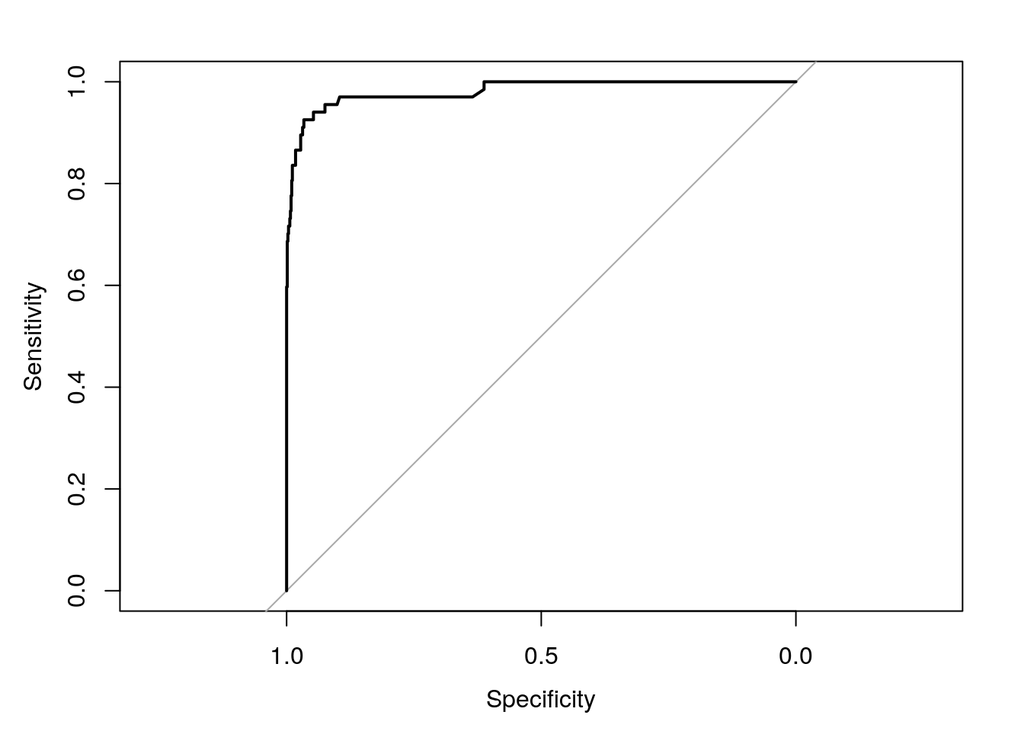

```r
# ROC Curve
prob=plogis(predict.glm(model.glm.final, type = c("response")))
#head(prob)
h <- roc(Oscars_won_some~prob, data=oscars_train)
plot(h)
```

```r
# Area Under the Curve
auc(h)
```

```
## Area under the curve: 0.9815
```

The ROC plot shows a definite improvement relative to the previous model, and the AUC is increased by ~3 percentage points (total of ~98%).

Lastly, let us cross-validate:

```r
#FTrain
model.glm.final.fTrain <- function(train_data) {
  return (
    glm(Oscars_won_some~awards_wins +
          Screen_Actors_Guild_won +
          Golden_Globes_won +
          genre_Drama +
          Writers_Guild_won +
          Online_Film_Television_Association_nominated +
          BAFTA_won,
        family = binomial(link = "logit"),
        data = train_data))
}

scores <- oscars %>% cross_validate(
  fTrain = model.glm.final.fTrain,
  fHitRate = model.glm.fHitRate)

scores
```

```
## [1] 0.9680851 0.9654255 0.9731903
```

```r
mean(scores)
```

```
## [1] 0.9689003
```

```r
sd(scores)
```

```
## [1] 0.003946078
```

The average accuracy from the cross-validation approach (96.89%) is comparable to the accuracy shown in our model trained only from a single training set (96.93%). The standard deviation of the cross-validation accuracy is also quite low, suggesting that our model is not overfitting our data.

We also need to confirm that we are not seeing a massive amount of multicollinearity:

```r
vif(model.glm.final)
```

```
##                                  awards_wins
##                                     5.008870
##                      Screen_Actors_Guild_won
##                                     1.377229
##                            Golden_Globes_won
##                                     1.530827
##                                  genre_Drama
##                                     1.175590
##                            Writers_Guild_won
##                                     1.697041
## Online_Film_Television_Association_nominated
##                                     4.987842
##                                    BAFTA_won
##                                     1.862242
```

Due to the large values for `award_wins` and `Online_Film_Television_Association_nominated`, we should probably repeat the stepwise regression process using a subset of the variables that are not the variables that are aggregated into `award_wins`, while keeping `award_wins` available for use by the stepwise variable selection process.

```r
oscars_train2 <- oscars_train %>% select(-matches(".*nominated$"), -matches(".*won$"))
oscars_test2 <- oscars_test %>% select(-matches(".*nominated$"), -matches(".*won$"))

# creating a null model
model.glm.null2 <-  glm(Oscars_won_some~1,
                family = binomial(link = "logit"), data = oscars_train2)
# create a full model
model.glm.all2 <- glm(Oscars_won_some~.,
                family = binomial(link = "logit"), data = oscars_train2)
# use step to apply stepwise forward selection with BIC as a evaluation metric
model.glm.final2 <- step(model.glm.null2, scope = formula(model.glm.all2), direction = "forward", k = log(nrow(oscars_train)), trace = FALSE)
# NOTE: The output says AIC, but we really are calculating BIC, because we are using the log of the number of observations in our dataset as our penalty term (k) instead of just the number of predictors.
```

```r
summary(model.glm.final2)$coefficients
```

```
##                      Estimate Std. Error   z value     Pr(>|z|)
## (Intercept)        -6.0008516  0.8802371 -6.817313 9.275932e-12
## awards_wins         1.5875529  0.1667137  9.522632 1.688467e-21
## genre_DramaYes      2.4075518  0.8960833  2.686750 7.215094e-03
## genre_BiographyYes  1.6175967  0.4345676  3.722313 1.974058e-04
## certificate         0.7019449  0.2824370  2.485315 1.294369e-02
```

Restricting our variable selection to reduce the multicollinearity we saw before, has the step-wise variable selection giving us a final model with only 4 variables. We discovered that all of the ‘non-Oscar’_nominated and ‘non-Oscar’_won categories sum to the values in `awards_nominations` and `awards_wins` during the EDA process, therefore we realize that it is likely inappropriate to keep them all in the model while also including `awards_wins` and/or `awards_nominations`. `awards_wins` is still statistically significant in both models.

```r
model.glm.final2.test <- predict.glm(model.glm.final2,oscars_test2,type='response')
cm <- confusionMatrix(factor(ifelse(model.glm.final2.test > 0.5,"Yes","No")),y_test)
cm$table
```

```
##           Reference
## Prediction  No Yes
##        No  235   9
##        Yes   5  12
```

```r
cm$overall[1]
```

```
##  Accuracy
## 0.9463602
```

```r
cm$overall[5]
```

```
## AccuracyNull
##    0.9195402
```

Our Accuracy is still above the No Information Rate (AccuracyNull above), as with the previous model, but we did see a reduction of the overall prediction accuracy and true positive rates compared to the other step-wise model.

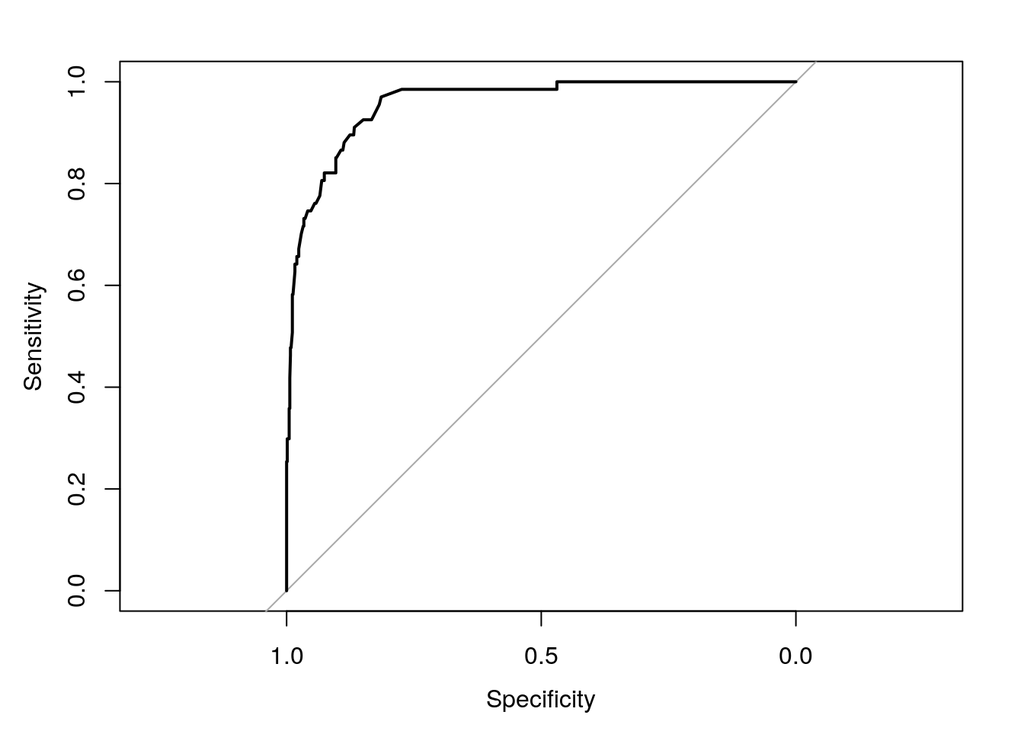

```r
# ROC Curve
prob=plogis(predict.glm(model.glm.final2, type = c("response")))
#head(prob)
h <- roc(Oscars_won_some~prob, data=oscars_train)
plot(h)
```

```r
# Area Under the Curve
auc(h)
```

```
## Area under the curve: 0.9582
```

AUC is lower than our initial forward selection model. However, the VIF statistic is improved relative to the previous model, as none of the variables have VIF scores above 2:

```r
vif(model.glm.final2)
```

```
##     awards_wins     genre_Drama genre_Biography     certificate
##        1.149884        1.120068        1.119833        1.153924
```

Finally, let us cross validate this model:

```r
# FTrain
model.glm.final2.fTrain <- function(train_data) {
  return(
    glm(Oscars_won_some~awards_wins +
          genre_Drama +
          genre_Biography +
          certificate,
        family = binomial(link = "logit"),
        data = train_data)
  )
}

scores <- oscars %>% cross_validate(
  fTrain = model.glm.final2.fTrain,
  fHitRate = model.glm.fHitRate
)

scores
```

```
## [1] 0.9627660 0.9441489 0.9517426
```

```r
mean(scores)
```

```
## [1] 0.9528858
```

```r
sd(scores)
```

```
## [1] 0.009361013
```

So in addition to this being a worse model in predictive performance than the previous model, it also has a higher variance. Thus, for now, Logistic Regression using the correlated variables gives the best results. The mutlicollinearity is only a problem for interpreting the Logistic Regression’s coefficients, but does not affect its predicitive capacity.

## 4.2 Random Forest

### 4.2.1 Default Random Forest

Now we will attempt to train a Random Forest model based on all the variables, and tune the hyperparameter `mtry` (the number of features used at each split), based on 3-fold cross-validated accuracy against the train data set:

```r
# apparently randomForest function can't use `-` in variable names.
oscars_train.renamed <- oscars_train %>%
  mutate(genre_Sci_Fi = `genre_Sci-Fi`) %>%
  select(-`genre_Sci-Fi`)
oscars_test.renamed <- oscars_test %>%
  mutate(genre_Sci_Fi = `genre_Sci-Fi`) %>%
  select(-`genre_Sci-Fi`)
oscars.renamed <- oscars %>%
  mutate(genre_Sci_Fi = `genre_Sci-Fi`) %>%
  select(-`genre_Sci-Fi`)

# Trains the model for each value of mtry
ranFor.train <- function(mtry, train.data,treez=500) {
  set.seed(42)
  return(randomForest(formula=Oscars_won_some~.,
               ntree=treez,
               importance=TRUE,
               proximity=TRUE,
               mtry=mtry,
               data=train.data))
}

# Tests the model
ranFor.hitrate <- function (model, test.data) {
  y_test_pred <- predict(model,test.data, type='response')
  return(sum(y_test_pred==test.data$Oscars_won_some)
         /length(test.data$Oscars_won_some))
}

# Tunes mtry using cross validation on the training set
# A list of the final mean cross-validated accuracies for each
# value of mtry
mtry_tuning <- function(train_data, num_trees, mrty_max){
  scores = c()
  # This is the same cross-val loop used on the function cross_validate
  # But only on the training data
  folds <- KFold(train_data$Oscars_won_some, n = 3,
                   stratified = TRUE, seed = 42)
  # Gets a list with the number of folds
  list_ = 1:length(folds)
  for (i in seq(1,mrty_max)) {
    # Gets a list to store the cross-val accuracies for different combination
    # of folds for training and testing
    scoress = c()
    # For each fold
    for(j in list_){
      # Gets the indexes for getting the training data
      list_train = list_[-j]
      train_index = c(folds[[list_train[1]]], folds[[list_train[2]]])
      # Gets the index for the testing data
      test_index = folds[[j]]
      # Splits between training and testing
      cv.train = train_data[train_index, ]
      cv.test = train_data[test_index, ]
      # Standardizes the new data
      scaleParam <- preProcess(cv.train, method=c("center", "scale"))
      cv.train <- predict(scaleParam, cv.train)
      cv.test <- predict(scaleParam, cv.test)
      # Trains the model for mtry=i
      trained.model <- ranFor.train(i, cv.train, num_trees)
      # Gets the cross-validated accuracies as a list
      scoress <- c(scoress, ranFor.hitrate(trained.model, cv.test))
    }
    # Appends to the final list the mean of the cross validated accuracies
    # for each mtry
    scores = c(scores, mean(scoress))
  }
  return(which(max(scores)==scores))
}

#mtry_tuning(oscars_train.renamed, 500, 80)
# The execution of the functin above is commented out because it takes a while to run
# Its output is:
# [1]  47

# Let's try it
best.ranFor.model = ranFor.train(47, oscars_train.renamed, 500)
y_test_pred <- predict(best.ranFor.model,oscars_test.renamed, type='response')

# confusion matrix
cm <- confusionMatrix(y_test_pred, y_test)
cm$table
```

```
##           Reference
## Prediction  No Yes
##        No  238   4
##        Yes   2  17
```

```r
cm$overall[1]
```

```
##  Accuracy
## 0.9770115
```

```r
cm$overall[5]
```

```
## AccuracyNull
##    0.9195402
```

Random Forest improves our prediction accuracy over the stepwise logistic regression model, at ~98% accuracy.

Note, although we can calculate the ROC AUC for random forests, it is calculated differently than for Logistic regression. For logistic regression, each ‘threshold’ on the ROC curve corresponds to the cutoff value used to determine which observations are classified as ‘1’s or ’0’s based on their fitted probabilities. In random forests, each ’threshold’ corresponds to the % of votes used to classify each observation as a 1. For example, each tree in a random forest gives a static rather than a probabilistic outcome. By default, the random forest assign ’1’s to observations that were classified as ’1’s in more than 50% of the trees and ’0’s to observations that were classified as ’1’s in 50% or less. We can change this threshold to determine how well our forest can choose between oscar and non-oscar winners at varying levels of consensus among trees.

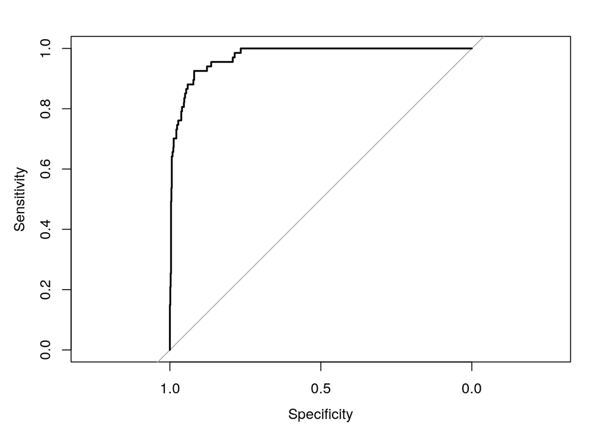

```r
#head(prob)
h <- roc(oscars_train.renamed$Oscars_won_some, best.ranFor.model$votes[, 2])
plot(h)
```

```r
# Area Under the Curve
auc(h)
```

```
## Area under the curve: 0.9731
```

```r
#fTrain
model.ranFor.fTrain <- function(train_data) {
  set.seed(42)
  return(
    randomForest(
      formula=Oscars_won_some~.,
      importance=TRUE,
      proximity=TRUE,
      mtry=47,
      data=train_data))
}

#fHitRate
model.ranFor.fHitRate <- function(pred_y, orig_y) {
  a <- sum(pred_y==orig_y)
  b <- length(orig_y)
  return (a/b)
}

scores <- oscars.renamed %>% cross_validate(
  fTrain = model.ranFor.fTrain,
  fHitRate = model.ranFor.fHitRate
)

scores
```

```
## [1] 0.9680851 0.9468085 0.9651475
```

```r
mean(scores)
```

```
## [1] 0.9600137
```

```r
sd(scores)
```

```
## [1] 0.01152996
```

However, we see that our cross-validated accuracy is lower than that of the Logistic Regression, and we also have a higher standard deviation. This means that this Random Forest is overfitting more to the training data than our Logistic Regression, and thus the results are less reliable. This also agrees with the lower ROC AUC.

Finally, let us compute the importance of each variable, because we have 81 variables; the default plot for this is very hard to read. So we are only showing the top 5:

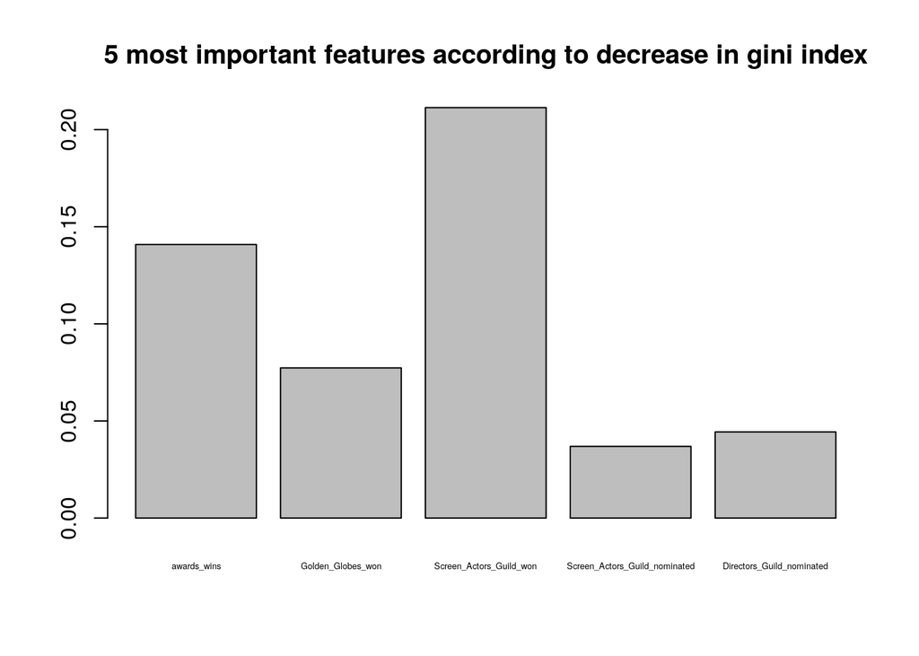

```r
# Computes the importance of each variable by impurity
imp = function(model){
  VI_F2 = importance(model, type=2)
  return(VI_F2/sum(VI_F2))
}
# https://freakonometrics.hypotheses.org/19835
# barplot(t(imp(best.ranFor.model)), cex.names=0.5)

plot_top_5_imp = function(VI_F2){
  rns = rownames(VI_F2)
  VI_F2 = cbind(VI_F2,data.frame(rns))
  VI_F2[,1] = VI_F2[,1]/sum(VI_F2[,1])

  top5 = VI_F2[which(VI_F2[,1]%in%sort(VI_F2[,1])[(nrow(VI_F2)-4):nrow(VI_F2)]),]
  top5[1,2]
  # https://freakonometrics.hypotheses.org/19835
  barplot(top5[,1],names= top5[,2],cex.names=.4,
          main= "5 most important features according to decrease in gini index"
    )
}

plot_top_5_imp(imp(best.ranFor.model))
```

Obviously, the number of non-oscar awards won by a movie from a specific organization is going to be correlated with the total number of non-oscar awards won by that movie (same with nominations), so interpreting individual feature importances is not entirely clear, but since we grew 500 trees that used roughly half of the variables at each split, we have reason to believe that at least some trees were grown without using the aggregated variables in the initial splits (giving the plethora of individual non-oscar award variables a chance to yield the best initial split and yield the highest decrease in the gini index.)